# ANCOVA in flow (debat) (flow (debat))

Geiser C. Challco geiser@alumni.usp.br

- Setting Initial Variables
- Descriptive Statistics of Initial Data
- ANCOVA and Pairwise for one factor: **grupo**
  - Without remove non-normal data
  - Computing ANCOVA and PairWise After removing non-normal data (OK)
    - Plots for ancova
    - Checking linearity assumption
    - Checking normality and homogeneity
- ANCOVA and Pairwise for two factors **grupo:Sexo**
  - Without remove non-normal data
  - Computing ANCOVA and PairWise After removing non-normal data (OK)
    - Plots for ancova
    - Checking linearity assumption
    - Checking normality and homogeneity
- ANCOVA and Pairwise for two factors **grupo:Zona**
  - Without remove non-normal data
  - Computing ANCOVA and PairWise After removing non-normal data (OK)
    - Plots for ancova
    - Checking linearity assumption
    - Checking normality and homogeneity
- ANCOVA and Pairwise for two factors **grupo:Cor.Raca**
  - Without remove non-normal data
  - Computing ANCOVA and PairWise After removing non-normal data (OK)
    - Plots for ancova
    - Checking linearity assumption
    - Checking normality and homogeneity
- ANCOVA and Pairwise for two factors **grupo:Serie**
  - Without remove non-normal data
  - Computing ANCOVA and PairWise After removing non-normal data (OK)
    - Plots for ancova
    - Checking linearity assumption
    - Checking normality and homogeneity
- Summary of Results
  - Descriptive Statistics
  - ANCOVA Table Comparison
  - PairWise Table Comparison
  - EMMS Table Comparison

**NOTE**:

- Teste ANCOVA para determinar se houve diferenças significativas no flow (debat) (medido usando pre- e pos-testes).
- ANCOVA test to determine whether there were significant differences in flow (debat) (measured using pre- and post-tests).

# Setting Initial Variables

```r
dv = "flow.debat"
dv.pos = "fss.media.debat"
dv.pre = "dfs.media.debat"

fatores2 <- c("Sexo","Zona","Cor.Raca","Serie")
lfatores2 <- as.list(fatores2)
names(lfatores2) <- fatores2

fatores1 <- c("grupo", fatores2)
lfatores1 <- as.list(fatores1)
names(lfatores1) <- fatores1

lfatores <- c(lfatores1)

color <- list()
color[["prepost"]] = c("#ffee65","#f28e2B")
color[["grupo"]] = c("#bcbd22","#008000")
color[["Sexo"]] = c("#FF007F","#4D4DFF")
color[["Zona"]] = c("#AA00FF","#00CCCC")
color[["Cor.Raca"]] = c(
  "Parda"="#b97100","Indígena"="#9F262F",
  "Branca"="#87c498", "Preta"="#848283","Amarela"="#D6B91C"
)

level <- list()
level[["grupo"]] = c("Controle","Experimental")
level[["Sexo"]] = c("F","M")
level[["Zona"]] = c("Rural","Urbana")
level[["Cor.Raca"]] = c("Parda","Indígena","Branca", "Preta","Amarela")
level[["Serie"]] = c("6 ano","7 ano","8 ano","9 ano")

# ..

ymin <- 0
ymax <- 0

ymin.ci <- 0
ymax.ci <- 0


color[["grupo:Sexo"]] = c(
  "Controle:F"="#ff99cb", "Controle:M"="#b7b7ff",
  "Experimental:F"="#FF007F", "Experimental:M"="#4D4DFF",
  "Controle.F"="#ff99cb", "Controle.M"="#b7b7ff",
  "Experimental.F"="#FF007F", "Experimental.M"="#4D4DFF"
)
color[["grupo:Zona"]] = c(
  "Controle:Rural"="#b2efef","Controle:Urbana"="#e5b2ff",
  "Experimental:Rural"="#00CCCC", "Experimental:Urbana"="#AA00FF",
  "Controle.Rural"="#b2efef","Controle.Urbana"="#e5b2ff",
  "Experimental.Rural"="#00CCCC", "Experimental.Urbana"="#AA00FF"
)
color[["grupo:Cor.Raca"]] = c(
    "Controle:Parda"="#e3c699", "Experimental:Parda"="#b97100",
    "Controle:Indígena"="#e2bdc0", "Experimental:Indígena"="#9F262F",
    "Controle:Branca"="#c0e8cb", "Experimental:Branca"="#87c498",
    "Controle:Preta"="#dad9d9", "Experimental:Preta"="#848283",
    "Controle:Amarela"="#eee3a4", "Experimental:Amarela"="#D6B91C",

    "Controle.Parda"="#e3c699", "Experimental.Parda"="#b97100",
    "Controle.Indígena"="#e2bdc0", "Experimental.Indígena"="#9F262F",
    "Controle.Branca"="#c0e8cb", "Experimental.Branca"="#87c498",
    "Controle.Preta"="#dad9d9", "Experimental.Preta"="#848283",
    "Controle.Amarela"="#eee3a4", "Experimental.Amarela"="#D6B91C"
)


for (coln in c("vocab","vocab.teach","vocab.non.teach","score.tde",
               "TFL.lidas.per.min","TFL.corretas.per.min","TFL.erradas.per.min","TFL.omitidas.per.min",
               "leitura.compreensao")) {
  color[[paste0(coln,".quintile")]] = c("#BF0040","#FF0000","#800080","#0000FF","#4000BF")
  level[[paste0(coln,".quintile")]] = c("1st quintile","2nd quintile","3rd quintile","4th quintile","5th quintile")
  color[[paste0("grupo:",coln,".quintile")]] = c(
    "Experimental.1st quintile"="#BF0040", "Controle.1st quintile"="#d8668c",
    "Experimental.2nd quintile"="#FF0000", "Controle.2nd quintile"="#ff7f7f",
    "Experimental.3rd quintile"="#8fce00", "Controle.3rd quintile"="#ddf0b2",
    "Experimental.4th quintile"="#0000FF", "Controle.4th quintile"="#b2b2ff",
    "Experimental.5th quintile"="#4000BF", "Controle.5th quintile"="#b299e5",

    "Experimental:1st quintile"="#BF0040", "Controle:1st quintile"="#d8668c",
    "Experimental:2nd quintile"="#FF0000", "Controle:2nd quintile"="#ff7f7f",
    "Experimental:3rd quintile"="#8fce00", "Controle:3rd quintile"="#ddf0b2",
    "Experimental:4th quintile"="#0000FF", "Controle:4th quintile"="#b2b2ff",
    "Experimental:5th quintile"="#4000BF", "Controle:5th quintile"="#b299e5")
}


gdat <- read_excel("../data/data.xlsx", sheet = "sumary")
gdat <- gdat[which(is.na(gdat$Necessidade.Deficiencia) & !is.na(gdat$WG.Grupo)),]



dat <- gdat
dat$grupo <- factor(dat[["WG.Grupo"]], level[["grupo"]])
for (coln in c(names(lfatores))) {
  dat[[coln]] <- factor(dat[[coln]], level[[coln]][level[[coln]] %in% unique(dat[[coln]])])
}
dat <- dat[which(!is.na(dat[[dv.pre]]) & !is.na(dat[[dv.pos]])),]
dat <- dat[,c("id",names(lfatores),dv.pre,dv.pos)]

dat.long <- rbind(dat, dat)
dat.long$time <- c(rep("pre", nrow(dat)), rep("pos", nrow(dat)))
dat.long$time <- factor(dat.long$time, c("pre","pos"))
dat.long[[dv]] <- c(dat[[dv.pre]], dat[[dv.pos]])


for (f in c("grupo", names(lfatores))) {
  if (is.null(color[[f]]) && length(unique(dat[[f]])) > 0)
      color[[f]] <- distinctColorPalette(length(unique(dat[[f]])))
}
for (f in c(fatores2)) {
  if (is.null(color[[paste0("grupo:",f)]]) && length(unique(dat[[f]])) > 0)
    color[[paste0("grupo:",f)]] <- distinctColorPalette(length(unique(dat[["grupo"]]))*length(unique(dat[[f]])))
}

ldat <- list()
laov <- list()
lpwc <- list()
lemms <- list()
```

# Descriptive Statistics of Initial Data

```r
df <- get.descriptives(dat, c(dv.pre, dv.pos), c("grupo"),
                       include.global = T, symmetry.test = T, normality.test = F)
df <- plyr::rbind.fill(
  df, do.call(plyr::rbind.fill, lapply(lfatores2, FUN = function(f) {
    if (nrow(dat) > 0 && sum(!is.na(unique(dat[[f]]))) > 1)
      get.descriptives(dat, c(dv.pre,dv.pos), c("grupo", f),
                       symmetry.test = T, normality.test = F)
    }))
)
df <- df[,c(fatores1[fatores1 %in% colnames(df)],"variable",
            colnames(df)[!colnames(df) %in% c(fatores1,"variable")])]
```

| grupo | Sexo | Zona | Cor.Raca | Serie | variable | n | mean | median | min | max | sd | se | ci | iqr | symmetry | skewness | kurtosis |
| --- | --- | --- | --- | --- | --- | --- | --- | --- | --- | --- | --- | --- | --- | --- | --- | --- | --- |
| Controle |  |  |  |  | dfs.media.debat | 458 | 3.438 | 3.444 | 1.000 | 5.000 | 0.587 | 0.027 | 0.054 | 0.778 | YES | -0.200 | 0.312 |
| Experimental |  |  |  |  | dfs.media.debat | 639 | 3.460 | 3.444 | 1.000 | 5.000 | 0.580 | 0.023 | 0.045 | 0.778 | YES | -0.260 | 0.508 |
|  |  |  |  |  | dfs.media.debat | 1097 | 3.450 | 3.444 | 1.000 | 5.000 | 0.583 | 0.018 | 0.035 | 0.778 | YES | -0.235 | 0.428 |
| Controle |  |  |  |  | fss.media.debat | 458 | 3.430 | 3.444 | 1.000 | 5.000 | 0.622 | 0.029 | 0.057 | 0.889 | YES | -0.308 | 0.333 |
| Experimental |  |  |  |  | fss.media.debat | 639 | 3.475 | 3.444 | 1.000 | 5.000 | 0.600 | 0.024 | 0.047 | 0.833 | YES | -0.144 | 0.402 |
|  |  |  |  |  | fss.media.debat | 1097 | 3.456 | 3.444 | 1.000 | 5.000 | 0.609 | 0.018 | 0.036 | 0.889 | YES | -0.221 | 0.394 |
| Controle | F |  |  |  | dfs.media.debat | 229 | 3.517 | 3.556 | 1.444 | 4.889 | 0.539 | 0.036 | 0.070 | 0.778 | YES | -0.348 | 0.348 |
| Controle | M |  |  |  | dfs.media.debat | 229 | 3.358 | 3.333 | 1.000 | 5.000 | 0.622 | 0.041 | 0.081 | 0.778 | YES | -0.013 | 0.295 |
| Experimental | F |  |  |  | dfs.media.debat | 326 | 3.501 | 3.444 | 1.667 | 5.000 | 0.547 | 0.030 | 0.060 | 0.778 | YES | -0.066 | -0.213 |
| Experimental | M |  |  |  | dfs.media.debat | 313 | 3.416 | 3.444 | 1.000 | 5.000 | 0.610 | 0.034 | 0.068 | 0.778 | YES | -0.364 | 0.825 |
| Controle | F |  |  |  | fss.media.debat | 229 | 3.481 | 3.556 | 1.444 | 5.000 | 0.598 | 0.040 | 0.078 | 0.778 | YES | -0.332 | -0.039 |
| Controle | M |  |  |  | fss.media.debat | 229 | 3.379 | 3.444 | 1.000 | 5.000 | 0.643 | 0.042 | 0.084 | 0.778 | YES | -0.259 | 0.569 |
| Experimental | F |  |  |  | fss.media.debat | 326 | 3.484 | 3.556 | 1.000 | 5.000 | 0.630 | 0.035 | 0.069 | 0.778 | YES | -0.297 | 0.604 |
| Experimental | M |  |  |  | fss.media.debat | 313 | 3.465 | 3.444 | 2.000 | 5.000 | 0.567 | 0.032 | 0.063 | 0.889 | YES | 0.064 | -0.009 |
| Controle |  | Rural |  |  | dfs.media.debat | 228 | 3.510 | 3.472 | 2.250 | 4.889 | 0.524 | 0.035 | 0.068 | 0.767 | YES | 0.123 | -0.237 |
| Controle |  | Urbana |  |  | dfs.media.debat | 110 | 3.402 | 3.389 | 1.889 | 4.778 | 0.627 | 0.060 | 0.119 | 0.833 | YES | -0.160 | -0.538 |
| Controle |  |  |  |  | dfs.media.debat | 120 | 3.333 | 3.333 | 1.000 | 5.000 | 0.644 | 0.059 | 0.116 | 0.806 | YES | -0.361 | 0.776 |
| Experimental |  | Rural |  |  | dfs.media.debat | 249 | 3.430 | 3.444 | 1.333 | 4.778 | 0.568 | 0.036 | 0.071 | 0.778 | YES | -0.320 | 0.370 |
| Experimental |  | Urbana |  |  | dfs.media.debat | 173 | 3.487 | 3.444 | 1.889 | 5.000 | 0.578 | 0.044 | 0.087 | 0.764 | YES | -0.158 | 0.394 |
| Experimental |  |  |  |  | dfs.media.debat | 217 | 3.471 | 3.444 | 1.000 | 5.000 | 0.596 | 0.040 | 0.080 | 0.778 | YES | -0.279 | 0.631 |
| Controle |  | Rural |  |  | fss.media.debat | 228 | 3.469 | 3.528 | 2.000 | 5.000 | 0.578 | 0.038 | 0.075 | 0.778 | YES | -0.090 | -0.048 |
| Controle |  | Urbana |  |  | fss.media.debat | 110 | 3.455 | 3.528 | 1.444 | 4.889 | 0.624 | 0.060 | 0.118 | 0.889 | YES | -0.373 | 0.039 |
| Controle |  |  |  |  | fss.media.debat | 120 | 3.333 | 3.333 | 1.000 | 5.000 | 0.692 | 0.063 | 0.125 | 1.000 | YES | -0.386 | 0.426 |
| Experimental |  | Rural |  |  | fss.media.debat | 249 | 3.481 | 3.444 | 1.000 | 5.000 | 0.583 | 0.037 | 0.073 | 0.778 | YES | -0.384 | 1.067 |
| Experimental |  | Urbana |  |  | fss.media.debat | 173 | 3.473 | 3.444 | 2.000 | 5.000 | 0.599 | 0.046 | 0.090 | 0.889 | YES | 0.192 | -0.044 |
| Experimental |  |  |  |  | fss.media.debat | 217 | 3.469 | 3.556 | 1.333 | 5.000 | 0.621 | 0.042 | 0.083 | 0.889 | YES | -0.152 | 0.047 |
| Controle |  |  | Parda |  | dfs.media.debat | 160 | 3.364 | 3.444 | 1.000 | 4.778 | 0.597 | 0.047 | 0.093 | 0.778 | YES | -0.392 | 0.713 |
| Controle |  |  | Indígena |  | dfs.media.debat | 10 | 3.708 | 3.708 | 3.333 | 4.222 | 0.273 | 0.086 | 0.195 | 0.417 | YES | 0.298 | -1.135 |
| Controle |  |  | Branca |  | dfs.media.debat | 47 | 3.504 | 3.444 | 2.111 | 4.889 | 0.628 | 0.092 | 0.184 | 0.833 | YES | 0.137 | -0.416 |
| Controle |  |  | Preta |  | dfs.media.debat | 1 | 3.556 | 3.556 | 3.556 | 3.556 |  |  |  | 0.000 | few data | 0.000 | 0.000 |
| Controle |  |  |  |  | dfs.media.debat | 240 | 3.462 | 3.444 | 1.444 | 5.000 | 0.578 | 0.037 | 0.074 | 0.694 | YES | -0.096 | -0.075 |
| Experimental |  |  | Parda |  | dfs.media.debat | 172 | 3.367 | 3.333 | 1.333 | 4.778 | 0.554 | 0.042 | 0.083 | 0.667 | YES | -0.090 | 0.592 |
| Experimental |  |  | Indígena |  | dfs.media.debat | 15 | 3.310 | 3.222 | 2.667 | 4.333 | 0.503 | 0.130 | 0.279 | 0.556 | NO | 0.712 | -0.740 |
| Experimental |  |  | Branca |  | dfs.media.debat | 57 | 3.439 | 3.444 | 2.111 | 4.333 | 0.508 | 0.067 | 0.135 | 0.667 | YES | -0.441 | -0.327 |
| Experimental |  |  | Preta |  | dfs.media.debat | 1 | 3.222 | 3.222 | 3.222 | 3.222 |  |  |  | 0.000 | few data | 0.000 | 0.000 |
| Experimental |  |  | Amarela |  | dfs.media.debat | 1 | 3.444 | 3.444 | 3.444 | 3.444 |  |  |  | 0.000 | few data | 0.000 | 0.000 |
| Experimental |  |  |  |  | dfs.media.debat | 393 | 3.509 | 3.556 | 1.000 | 5.000 | 0.600 | 0.030 | 0.060 | 0.778 | YES | -0.373 | 0.599 |
| Controle |  |  | Parda |  | fss.media.debat | 160 | 3.408 | 3.444 | 1.000 | 5.000 | 0.640 | 0.051 | 0.100 | 0.889 | YES | -0.429 | 0.795 |
| Controle |  |  | Indígena |  | fss.media.debat | 10 | 3.700 | 3.778 | 2.556 | 4.333 | 0.516 | 0.163 | 0.369 | 0.389 | NO | -0.855 | -0.159 |
| Controle |  |  | Branca |  | fss.media.debat | 47 | 3.556 | 3.333 | 2.556 | 5.000 | 0.581 | 0.085 | 0.170 | 0.778 | YES | 0.487 | -0.790 |
| Controle |  |  | Preta |  | fss.media.debat | 1 | 3.333 | 3.333 | 3.333 | 3.333 |  |  |  | 0.000 | few data | 0.000 | 0.000 |
| Controle |  |  |  |  | fss.media.debat | 240 | 3.409 | 3.444 | 1.333 | 4.889 | 0.621 | 0.040 | 0.079 | 0.889 | YES | -0.301 | -0.030 |
| Experimental |  |  | Parda |  | fss.media.debat | 172 | 3.469 | 3.444 | 1.778 | 5.000 | 0.560 | 0.043 | 0.084 | 0.806 | YES | 0.115 | 0.240 |
| Experimental |  |  | Indígena |  | fss.media.debat | 15 | 3.227 | 3.125 | 2.222 | 4.222 | 0.584 | 0.151 | 0.323 | 0.722 | YES | -0.021 | -1.094 |
| Experimental |  |  | Branca |  | fss.media.debat | 57 | 3.548 | 3.556 | 2.222 | 4.556 | 0.579 | 0.077 | 0.154 | 0.667 | YES | -0.415 | -0.393 |
| Experimental |  |  | Preta |  | fss.media.debat | 1 | 4.444 | 4.444 | 4.444 | 4.444 |  |  |  | 0.000 | few data | 0.000 | 0.000 |
| Experimental |  |  | Amarela |  | fss.media.debat | 1 | 3.556 | 3.556 | 3.556 | 3.556 |  |  |  | 0.000 | few data | 0.000 | 0.000 |
| Experimental |  |  |  |  | fss.media.debat | 393 | 3.474 | 3.556 | 1.000 | 5.000 | 0.618 | 0.031 | 0.061 | 0.778 | YES | -0.199 | 0.547 |
| Controle |  |  |  | 6 ano | dfs.media.debat | 151 | 3.475 | 3.444 | 1.444 | 4.889 | 0.625 | 0.051 | 0.100 | 0.833 | YES | -0.113 | -0.109 |
| Controle |  |  |  | 7 ano | dfs.media.debat | 123 | 3.404 | 3.444 | 1.889 | 4.889 | 0.584 | 0.053 | 0.104 | 0.778 | YES | -0.067 | -0.370 |
| Controle |  |  |  | 8 ano | dfs.media.debat | 80 | 3.453 | 3.444 | 2.500 | 5.000 | 0.506 | 0.057 | 0.113 | 0.778 | YES | 0.128 | -0.221 |
| Controle |  |  |  | 9 ano | dfs.media.debat | 104 | 3.411 | 3.444 | 1.000 | 4.667 | 0.596 | 0.058 | 0.116 | 0.667 | NO | -0.657 | 1.501 |
| Experimental |  |  |  | 6 ano | dfs.media.debat | 167 | 3.409 | 3.444 | 1.667 | 5.000 | 0.598 | 0.046 | 0.091 | 0.778 | YES | -0.015 | 0.179 |
| Experimental |  |  |  | 7 ano | dfs.media.debat | 177 | 3.463 | 3.444 | 1.333 | 4.667 | 0.566 | 0.043 | 0.084 | 0.778 | YES | -0.379 | 0.470 |
| Experimental |  |  |  | 8 ano | dfs.media.debat | 153 | 3.489 | 3.444 | 2.111 | 4.778 | 0.571 | 0.046 | 0.091 | 0.778 | YES | -0.051 | -0.639 |
| Experimental |  |  |  | 9 ano | dfs.media.debat | 142 | 3.482 | 3.556 | 1.000 | 5.000 | 0.588 | 0.049 | 0.098 | 0.667 | NO | -0.610 | 2.008 |
| Controle |  |  |  | 6 ano | fss.media.debat | 151 | 3.450 | 3.444 | 1.444 | 5.000 | 0.616 | 0.050 | 0.099 | 0.778 | YES | -0.199 | 0.145 |
| Controle |  |  |  | 7 ano | fss.media.debat | 123 | 3.374 | 3.444 | 2.111 | 4.556 | 0.526 | 0.047 | 0.094 | 0.778 | YES | -0.189 | -0.507 |
| Controle |  |  |  | 8 ano | fss.media.debat | 80 | 3.427 | 3.528 | 2.000 | 5.000 | 0.652 | 0.073 | 0.145 | 1.000 | YES | -0.082 | -0.422 |
| Controle |  |  |  | 9 ano | fss.media.debat | 104 | 3.471 | 3.556 | 1.000 | 5.000 | 0.710 | 0.070 | 0.138 | 0.917 | NO | -0.681 | 0.860 |
| Experimental |  |  |  | 6 ano | fss.media.debat | 167 | 3.415 | 3.444 | 1.333 | 5.000 | 0.602 | 0.047 | 0.092 | 0.778 | YES | -0.270 | 0.211 |
| Experimental |  |  |  | 7 ano | fss.media.debat | 177 | 3.551 | 3.556 | 1.778 | 5.000 | 0.591 | 0.044 | 0.088 | 0.778 | YES | 0.114 | 0.253 |
| Experimental |  |  |  | 8 ano | fss.media.debat | 153 | 3.382 | 3.333 | 1.000 | 5.000 | 0.637 | 0.052 | 0.102 | 0.778 | YES | -0.236 | 0.623 |
| Experimental |  |  |  | 9 ano | fss.media.debat | 142 | 3.552 | 3.556 | 2.000 | 5.000 | 0.547 | 0.046 | 0.091 | 0.778 | YES | -0.017 | -0.349 |

# ANCOVA and Pairwise for one factor: **grupo**

## Without remove non-normal data

```r
pdat = remove_group_data(dat[!is.na(dat[["grupo"]]),], "fss.media.debat", "grupo")

pdat.long <- rbind(pdat[,c("id","grupo")], pdat[,c("id","grupo")])
pdat.long[["time"]] <- c(rep("pre", nrow(pdat)), rep("pos", nrow(pdat)))
pdat.long[["time"]] <- factor(pdat.long[["time"]], c("pre","pos"))
pdat.long[["flow.debat"]] <- c(pdat[["dfs.media.debat"]], pdat[["fss.media.debat"]])

aov = anova_test(pdat, fss.media.debat ~ dfs.media.debat + grupo)
laov[["grupo"]] <- get_anova_table(aov)
```

```r
pwc <- emmeans_test(pdat, fss.media.debat ~ grupo, covariate = dfs.media.debat,
                    p.adjust.method = "bonferroni")
```

```r
pwc.long <- emmeans_test(dplyr::group_by_at(pdat.long, "grupo"),
                          flow.debat ~ time,
                          p.adjust.method = "bonferroni")
lpwc[["grupo"]] <- plyr::rbind.fill(pwc, pwc.long)
```

```r
ds <- get.descriptives(pdat, "fss.media.debat", "grupo", covar = "dfs.media.debat")
ds <- merge(ds[ds$variable != "dfs.media.debat",],
            ds[ds$variable == "dfs.media.debat", !colnames(ds) %in% c("variable")],
            by = "grupo", all.x = T, suffixes = c("", ".dfs.media.debat"))
ds <- merge(get_emmeans(pwc), ds, by = "grupo", suffixes = c(".emms", ""))
ds <- ds[,c("grupo","n","mean.dfs.media.debat","se.dfs.media.debat","mean","se",
            "emmean","se.emms","conf.low","conf.high")]

colnames(ds) <- c("grupo", "N", paste0(c("M","SE")," (pre)"),
                  paste0(c("M","SE"), " (unadj)"),
                  paste0(c("M", "SE"), " (adj)"), "conf.low", "conf.high")

lemms[["grupo"]] <- ds
```

## Computing ANCOVA and PairWise After removing non-normal data (OK)

```r
wdat = pdat

res = residuals(lm(fss.media.debat ~ dfs.media.debat + grupo, data = wdat))
non.normal = getNonNormal(res, wdat$id, plimit = 0.05)

wdat = wdat[!wdat$id %in% non.normal,]

wdat.long <- rbind(wdat[,c("id","grupo")], wdat[,c("id","grupo")])
wdat.long[["time"]] <- c(rep("pre", nrow(wdat)), rep("pos", nrow(wdat)))
wdat.long[["time"]] <- factor(wdat.long[["time"]], c("pre","pos"))
wdat.long[["flow.debat"]] <- c(wdat[["dfs.media.debat"]], wdat[["fss.media.debat"]])

ldat[["grupo"]] = wdat

(non.normal)
```

```
## [1] "P2207" "P1790"
```

```r
aov = anova_test(wdat, fss.media.debat ~ dfs.media.debat + grupo)
laov[["grupo"]] <- merge(get_anova_table(aov), laov[["grupo"]],
                            by="Effect", suffixes = c("","'"))

(df = get_anova_table(aov))
```

```
## ANOVA Table (type II tests)
##
##            Effect DFn  DFd       F        p p<.05   ges
## 1 dfs.media.debat   1 1092 193.494 1.29e-40     * 0.151
## 2           grupo   1 1092   1.645 2.00e-01       0.002
```

| Effect | DFn | DFd | F | p | p<.05 | ges |
| --- | --- | --- | --- | --- | --- | --- |
| dfs.media.debat | 1 | 1092 | 193.494 | 0.0 | * | 0.151 |
| grupo | 1 | 1092 | 1.645 | 0.2 |  | 0.002 |

```r
pwc <- emmeans_test(wdat, fss.media.debat ~ grupo, covariate = dfs.media.debat,
                    p.adjust.method = "bonferroni")
```

| term | .y. | group1 | group2 | df | statistic | p | p.adj | p.adj.signif |
| --- | --- | --- | --- | --- | --- | --- | --- | --- |
| dfs.media.debat*grupo | fss.media.debat | Controle | Experimental | 1092 | -1.283 | 0.2 | 0.2 | ns |

```r
pwc.long <- emmeans_test(dplyr::group_by_at(wdat.long, "grupo"),
                         flow.debat ~ time,
                         p.adjust.method = "bonferroni")
lpwc[["grupo"]] <- merge(plyr::rbind.fill(pwc, pwc.long), lpwc[["grupo"]],
                            by=c("grupo","term",".y.","group1","group2"),
                            suffixes = c("","'"))
```

| grupo | term | .y. | group1 | group2 | df | statistic | p | p.adj | p.adj.signif |
| --- | --- | --- | --- | --- | --- | --- | --- | --- | --- |
| Controle | time | flow.debat | pre | pos | 2186 | 0.192 | 0.848 | 0.848 | ns |
| Experimental | time | flow.debat | pre | pos | 2186 | -0.692 | 0.489 | 0.489 | ns |

```r
ds <- get.descriptives(wdat, "fss.media.debat", "grupo", covar = "dfs.media.debat")
ds <- merge(ds[ds$variable != "dfs.media.debat",],
            ds[ds$variable == "dfs.media.debat", !colnames(ds) %in% c("variable")],
            by = "grupo", all.x = T, suffixes = c("", ".dfs.media.debat"))
ds <- merge(get_emmeans(pwc), ds, by = "grupo", suffixes = c(".emms", ""))
ds <- ds[,c("grupo","n","mean.dfs.media.debat","se.dfs.media.debat","mean","se",
            "emmean","se.emms","conf.low","conf.high")]

colnames(ds) <- c("grupo", "N", paste0(c("M","SE")," (pre)"),
                  paste0(c("M","SE"), " (unadj)"),
                  paste0(c("M", "SE"), " (adj)"), "conf.low", "conf.high")

lemms[["grupo"]] <- merge(ds, lemms[["grupo"]], by=c("grupo"), suffixes = c("","'"))
```

| grupo | N | M (pre) | SE (pre) | M (unadj) | SE (unadj) | M (adj) | SE (adj) | conf.low | conf.high |
| --- | --- | --- | --- | --- | --- | --- | --- | --- | --- |
| Controle | 458 | 3.438 | 0.027 | 3.430 | 0.029 | 3.435 | 0.026 | 3.384 | 3.486 |
| Experimental | 637 | 3.459 | 0.023 | 3.482 | 0.023 | 3.479 | 0.022 | 3.436 | 3.522 |

### Plots for ancova

```r
plots <- oneWayAncovaPlots(
  wdat, "fss.media.debat", "grupo", aov, list("grupo"=pwc), addParam = c("mean_ci"),
  font.label.size=10, step.increase=0.05, p.label="p.adj",
  subtitle = which(aov$Effect == "grupo"))
```

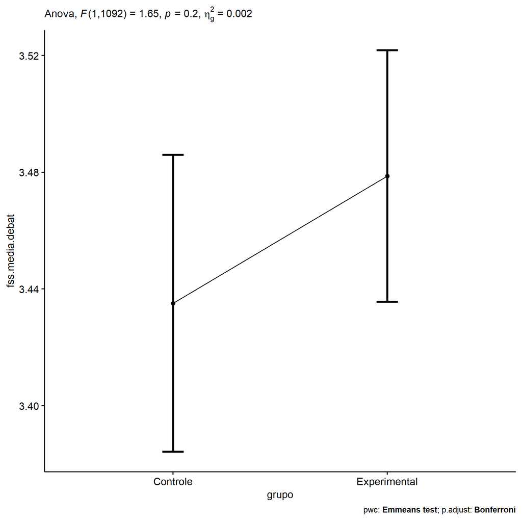

```r
if (!is.null(nrow(plots[["grupo"]]$data)))
  plots[["grupo"]] +
  if (ymin.ci < ymax.ci) ggplot2::ylim(ymin.ci, ymax.ci)
```

```r
plots <- oneWayAncovaBoxPlots(
  wdat, "fss.media.debat", "grupo", aov, pwc, covar = "dfs.media.debat",
  theme = "classic", color = color[["grupo"]],
  subtitle = which(aov$Effect == "grupo"))
```

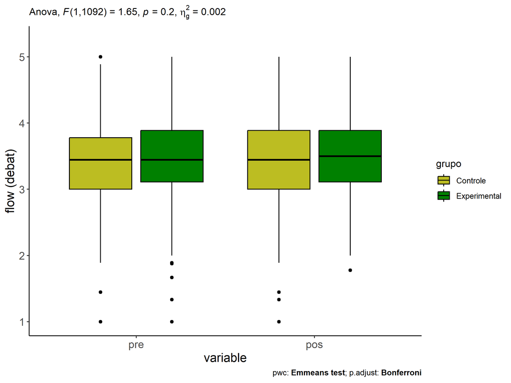

```r
if (length(unique(wdat[["grupo"]])) > 1)
  plots[["grupo"]] + ggplot2::ylab("flow (debat)") +
  ggplot2::scale_x_discrete(labels=c('pre', 'pos')) +
  if (ymin < ymax) ggplot2::ylim(ymin, ymax)
```

```r
if (length(unique(wdat.long[["grupo"]])) > 1)
  plots <- oneWayAncovaBoxPlots(
    wdat.long, "flow.debat", "grupo", aov, pwc.long,
    pre.post = "time", theme = "classic", color = color$prepost)
```

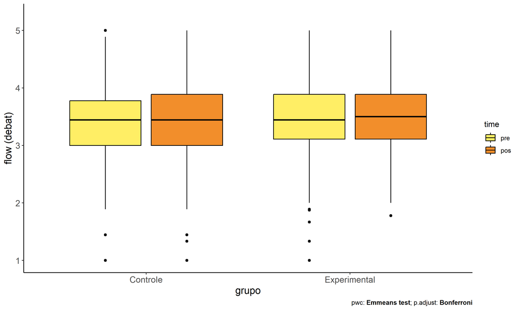

```r
if (length(unique(wdat.long[["grupo"]])) > 1)
  plots[["grupo"]] + ggplot2::ylab("flow (debat)") +
  if (ymin < ymax) ggplot2::ylim(ymin, ymax)
```

### Checking linearity assumption

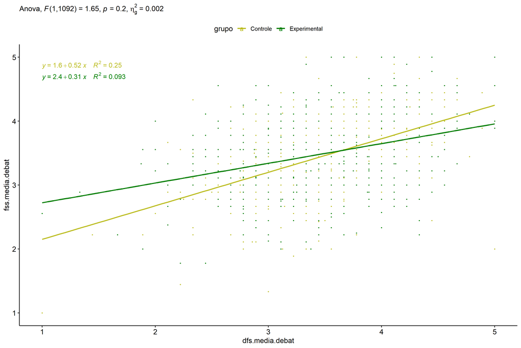

```r
ggscatter(wdat, x = "dfs.media.debat", y = "fss.media.debat", size = 0.5,
          color = "grupo", add = "reg.line")+
  stat_regline_equation(
    aes(label =  paste(..eq.label.., ..rr.label.., sep = "~~~~"), color = grupo)
  ) +
  ggplot2::labs(subtitle = rstatix::get_test_label(aov, detailed = T, row = which(aov$Effect == "grupo"))) +
  ggplot2::scale_color_manual(values = color[["grupo"]]) +
  if (ymin < ymax) ggplot2::ylim(ymin, ymax)
```

### Checking normality and homogeneity

```r
res <- augment(lm(fss.media.debat ~ dfs.media.debat + grupo, data = wdat))
```

```r
shapiro_test(res$.resid)
```

```
## # A tibble: 1 × 3
##   variable   statistic p.value
##   <chr>          <dbl>   <dbl>
## 1 res$.resid     0.997  0.0611
```

```r
levene_test(res, .resid ~ grupo)
```

```
## # A tibble: 1 × 4
##     df1   df2 statistic     p
##   <int> <int>     <dbl> <dbl>
## 1     1  1093      1.60 0.206
```

# ANCOVA and Pairwise for two factors **grupo:Sexo**

## Without remove non-normal data

```r
pdat = remove_group_data(dat[!is.na(dat[["grupo"]]) & !is.na(dat[["Sexo"]]),],
                         "fss.media.debat", c("grupo","Sexo"))
pdat = pdat[pdat[["Sexo"]] %in% do.call(
  intersect, lapply(unique(pdat[["grupo"]]), FUN = function(x) {
    unique(pdat[["Sexo"]][which(pdat[["grupo"]] == x)])
  })),]
pdat[["grupo"]] = factor(pdat[["grupo"]], level[["grupo"]])
pdat[["Sexo"]] = factor(
  pdat[["Sexo"]],
  level[["Sexo"]][level[["Sexo"]] %in% unique(pdat[["Sexo"]])])

pdat.long <- rbind(pdat[,c("id","grupo","Sexo")], pdat[,c("id","grupo","Sexo")])
pdat.long[["time"]] <- c(rep("pre", nrow(pdat)), rep("pos", nrow(pdat)))
pdat.long[["time"]] <- factor(pdat.long[["time"]], c("pre","pos"))
pdat.long[["flow.debat"]] <- c(pdat[["dfs.media.debat"]], pdat[["fss.media.debat"]])

if (length(unique(pdat[["Sexo"]])) >= 2) {
  aov = anova_test(pdat, fss.media.debat ~ dfs.media.debat + grupo*Sexo)
  laov[["grupo:Sexo"]] <- get_anova_table(aov)
}
```

```r
if (length(unique(pdat[["Sexo"]])) >= 2) {
  pwcs <- list()
  pwcs[["Sexo"]] <- emmeans_test(
    group_by(pdat, grupo), fss.media.debat ~ Sexo,
    covariate = dfs.media.debat, p.adjust.method = "bonferroni")
  pwcs[["grupo"]] <- emmeans_test(
    group_by(pdat, Sexo), fss.media.debat ~ grupo,
    covariate = dfs.media.debat, p.adjust.method = "bonferroni")

  pwc <- plyr::rbind.fill(pwcs[["grupo"]], pwcs[["Sexo"]])
  pwc <- pwc[,c("grupo","Sexo", colnames(pwc)[!colnames(pwc) %in% c("grupo","Sexo")])]
}
```

```r
if (length(unique(pdat[["Sexo"]])) >= 2) {
  pwc.long <- emmeans_test(dplyr::group_by_at(pdat.long, c("grupo","Sexo")),
                           flow.debat ~ time,
                           p.adjust.method = "bonferroni")
  lpwc[["grupo:Sexo"]] <- plyr::rbind.fill(pwc, pwc.long)
}
```

```r
if (length(unique(pdat[["Sexo"]])) >= 2) {
  ds <- get.descriptives(pdat, "fss.media.debat", c("grupo","Sexo"), covar = "dfs.media.debat")
  ds <- merge(ds[ds$variable != "dfs.media.debat",],
              ds[ds$variable == "dfs.media.debat", !colnames(ds) %in% c("variable")],
              by = c("grupo","Sexo"), all.x = T, suffixes = c("", ".dfs.media.debat"))
  ds <- merge(get_emmeans(pwcs[["grupo"]]), ds,
              by = c("grupo","Sexo"), suffixes = c(".emms", ""))
  ds <- ds[,c("grupo","Sexo","n","mean.dfs.media.debat","se.dfs.media.debat","mean","se",
              "emmean","se.emms","conf.low","conf.high")]

  colnames(ds) <- c("grupo","Sexo", "N", paste0(c("M","SE")," (pre)"),
                    paste0(c("M","SE"), " (unadj)"),
                    paste0(c("M", "SE"), " (adj)"), "conf.low", "conf.high")

  lemms[["grupo:Sexo"]] <- ds
}
```

## Computing ANCOVA and PairWise After removing non-normal data (OK)

```r
if (length(unique(pdat[["Sexo"]])) >= 2) {
  wdat = pdat

  res = residuals(lm(fss.media.debat ~ dfs.media.debat + grupo*Sexo, data = wdat))
  non.normal = getNonNormal(res, wdat$id, plimit = 0.05)

  wdat = wdat[!wdat$id %in% non.normal,]

  wdat.long <- rbind(wdat[,c("id","grupo","Sexo")], wdat[,c("id","grupo","Sexo")])
  wdat.long[["time"]] <- c(rep("pre", nrow(wdat)), rep("pos", nrow(wdat)))
  wdat.long[["time"]] <- factor(wdat.long[["time"]], c("pre","pos"))
  wdat.long[["flow.debat"]] <- c(wdat[["dfs.media.debat"]], wdat[["fss.media.debat"]])


  ldat[["grupo:Sexo"]] = wdat

  (non.normal)
}
```

```
## [1] "P2207" "P1790"
```

```r
if (length(unique(pdat[["Sexo"]])) >= 2) {
  aov = anova_test(wdat, fss.media.debat ~ dfs.media.debat + grupo*Sexo)
  laov[["grupo:Sexo"]] <- merge(get_anova_table(aov), laov[["grupo:Sexo"]],
                                         by="Effect", suffixes = c("","'"))
  df = get_anova_table(aov)
}
```

| Effect | DFn | DFd | F | p | p<.05 | ges |
| --- | --- | --- | --- | --- | --- | --- |
| dfs.media.debat | 1 | 1090 | 189.370 | 0.000 | * | 0.148 |
| grupo | 1 | 1090 | 1.635 | 0.201 |  | 0.001 |
| Sexo | 1 | 1090 | 0.212 | 0.645 |  | 0.000 |
| grupo:Sexo | 1 | 1090 | 0.308 | 0.579 |  | 0.000 |

```r
if (length(unique(pdat[["Sexo"]])) >= 2) {
  pwcs <- list()
  pwcs[["Sexo"]] <- emmeans_test(
    group_by(wdat, grupo), fss.media.debat ~ Sexo,
    covariate = dfs.media.debat, p.adjust.method = "bonferroni")
  pwcs[["grupo"]] <- emmeans_test(
    group_by(wdat, Sexo), fss.media.debat ~ grupo,
    covariate = dfs.media.debat, p.adjust.method = "bonferroni")

  pwc <- plyr::rbind.fill(pwcs[["grupo"]], pwcs[["Sexo"]])
  pwc <- pwc[,c("grupo","Sexo", colnames(pwc)[!colnames(pwc) %in% c("grupo","Sexo")])]
}
```

| grupo | Sexo | term | .y. | group1 | group2 | df | statistic | p | p.adj | p.adj.signif |
| --- | --- | --- | --- | --- | --- | --- | --- | --- | --- | --- |
|  | F | dfs.media.debat*grupo | fss.media.debat | Controle | Experimental | 1090 | -0.516 | 0.606 | 0.606 | ns |
|  | M | dfs.media.debat*grupo | fss.media.debat | Controle | Experimental | 1090 | -1.294 | 0.196 | 0.196 | ns |
| Controle |  | dfs.media.debat*Sexo | fss.media.debat | F | M | 1090 | 0.721 | 0.471 | 0.471 | ns |
| Experimental |  | dfs.media.debat*Sexo | fss.media.debat | F | M | 1090 | -0.005 | 0.996 | 0.996 | ns |

```r
if (length(unique(pdat[["Sexo"]])) >= 2) {
  pwc.long <- emmeans_test(dplyr::group_by_at(wdat.long, c("grupo","Sexo")),
                           flow.debat ~ time,
                           p.adjust.method = "bonferroni")
  lpwc[["grupo:Sexo"]] <- merge(plyr::rbind.fill(pwc, pwc.long),
                                         lpwc[["grupo:Sexo"]],
                                         by=c("grupo","Sexo","term",".y.","group1","group2"),
                                         suffixes = c("","'"))
}
```

| grupo | Sexo | term | .y. | group1 | group2 | df | statistic | p | p.adj | p.adj.signif |
| --- | --- | --- | --- | --- | --- | --- | --- | --- | --- | --- |
| Controle | F | time | flow.debat | pre | pos | 2182 | 0.666 | 0.505 | 0.505 | ns |
| Controle | M | time | flow.debat | pre | pos | 2182 | -0.394 | 0.694 | 0.694 | ns |
| Experimental | F | time | flow.debat | pre | pos | 2182 | 0.045 | 0.964 | 0.964 | ns |
| Experimental | M | time | flow.debat | pre | pos | 2182 | -1.035 | 0.301 | 0.301 | ns |

```r
if (length(unique(pdat[["Sexo"]])) >= 2) {
  ds <- get.descriptives(wdat, "fss.media.debat", c("grupo","Sexo"), covar = "dfs.media.debat")
  ds <- merge(ds[ds$variable != "dfs.media.debat",],
              ds[ds$variable == "dfs.media.debat", !colnames(ds) %in% c("variable")],
              by = c("grupo","Sexo"), all.x = T, suffixes = c("", ".dfs.media.debat"))
  ds <- merge(get_emmeans(pwcs[["grupo"]]), ds,
              by = c("grupo","Sexo"), suffixes = c(".emms", ""))
  ds <- ds[,c("grupo","Sexo","n","mean.dfs.media.debat","se.dfs.media.debat",
              "mean","se","emmean","se.emms","conf.low","conf.high")]

  colnames(ds) <- c("grupo","Sexo", "N", paste0(c("M","SE")," (pre)"),
                    paste0(c("M","SE"), " (unadj)"),
                    paste0(c("M", "SE"), " (adj)"), "conf.low", "conf.high")

  lemms[["grupo:Sexo"]] <- merge(ds, lemms[["grupo:Sexo"]],
                                          by=c("grupo","Sexo"), suffixes = c("","'"))
}
```

| grupo | Sexo | N | M (pre) | SE (pre) | M (unadj) | SE (unadj) | M (adj) | SE (adj) | conf.low | conf.high |
| --- | --- | --- | --- | --- | --- | --- | --- | --- | --- | --- |
| Controle | F | 229 | 3.517 | 0.036 | 3.481 | 0.040 | 3.454 | 0.037 | 3.382 | 3.526 |
| Controle | M | 229 | 3.358 | 0.041 | 3.379 | 0.042 | 3.416 | 0.037 | 3.344 | 3.488 |
| Experimental | F | 324 | 3.501 | 0.030 | 3.499 | 0.034 | 3.479 | 0.031 | 3.418 | 3.539 |
| Experimental | M | 313 | 3.416 | 0.034 | 3.465 | 0.032 | 3.479 | 0.031 | 3.417 | 3.540 |

### Plots for ancova

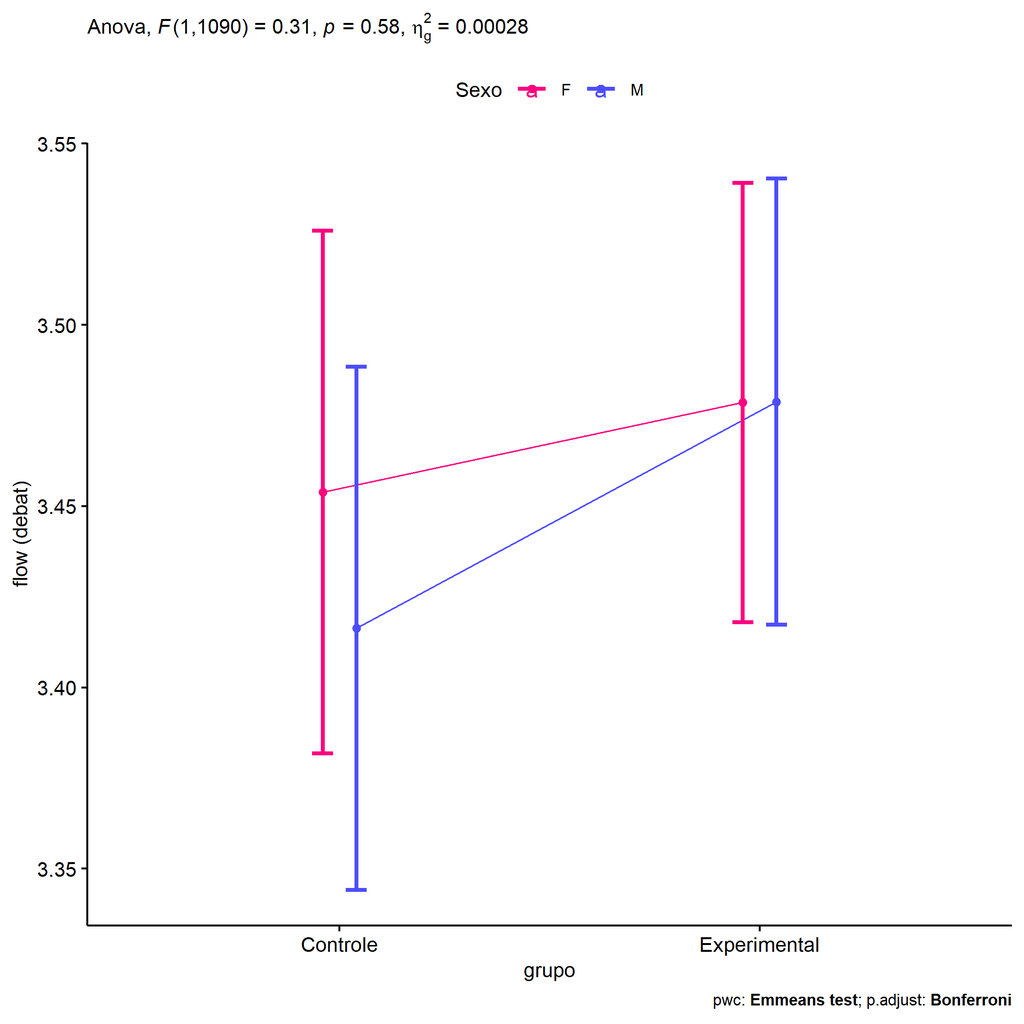

```r
if (length(unique(pdat[["Sexo"]])) >= 2) {
  ggPlotAoC2(pwcs, "grupo", "Sexo", aov, ylab = "flow (debat)",
             subtitle = which(aov$Effect == "grupo:Sexo"), addParam = "errorbar") +
    ggplot2::scale_color_manual(values = color[["Sexo"]]) +
    if (ymin.ci < ymax.ci) ggplot2::ylim(ymin.ci, ymax.ci)
}
```

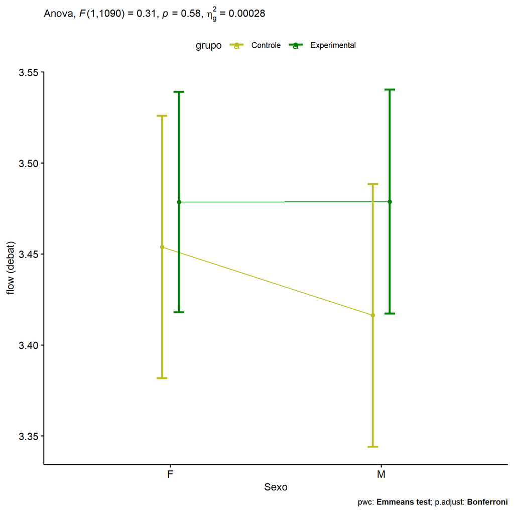

```r
if (length(unique(pdat[["Sexo"]])) >= 2) {
  ggPlotAoC2(pwcs, "Sexo", "grupo", aov, ylab = "flow (debat)",
               subtitle = which(aov$Effect == "grupo:Sexo"), addParam = "errorbar") +
      ggplot2::scale_color_manual(values = color[["grupo"]]) +
      if (ymin.ci < ymax.ci) ggplot2::ylim(ymin.ci, ymax.ci)
}
```

```r
if (length(unique(pdat[["Sexo"]])) >= 2) {
  plots <- twoWayAncovaBoxPlots(
    wdat, "fss.media.debat", c("grupo","Sexo"), aov, pwcs, covar = "dfs.media.debat",
    theme = "classic", color = color[["grupo:Sexo"]],
    subtitle = which(aov$Effect == "grupo:Sexo"))
}
```

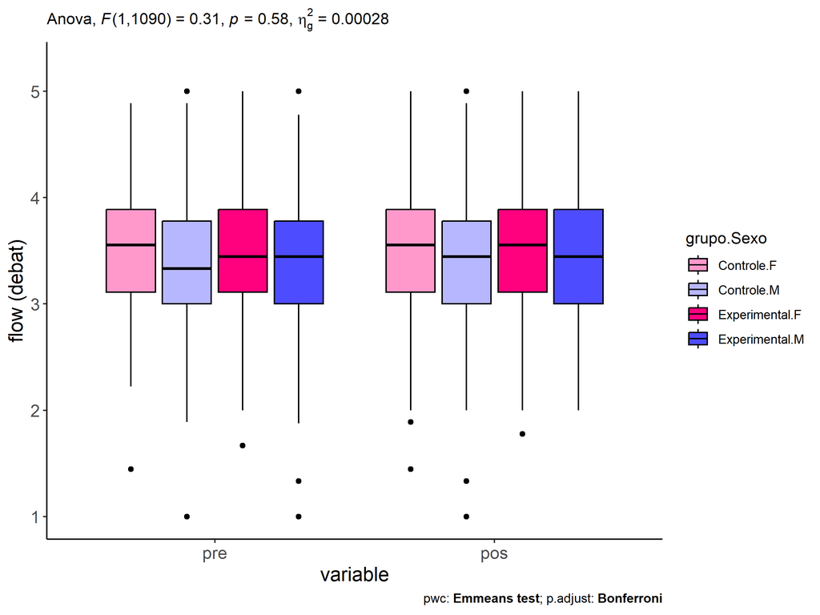

```r
if (length(unique(pdat[["Sexo"]])) >= 2) {
  plots[["grupo:Sexo"]] + ggplot2::ylab("flow (debat)") +
  ggplot2::scale_x_discrete(labels=c('pre', 'pos')) +
  if (ymin < ymax) ggplot2::ylim(ymin, ymax)
}
```

```r
if (length(unique(pdat[["Sexo"]])) >= 2) {
  plots <- twoWayAncovaBoxPlots(
    wdat.long, "flow.debat", c("grupo","Sexo"), aov, pwc.long,
    pre.post = "time",
    theme = "classic", color = color$prepost)
}
```

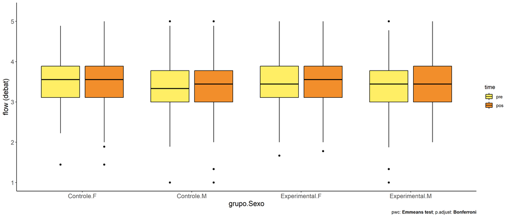

```r
if (length(unique(pdat[["Sexo"]])) >= 2)
  plots[["grupo:Sexo"]] + ggplot2::ylab("flow (debat)") +
    if (ymin < ymax) ggplot2::ylim(ymin, ymax)
```

### Checking linearity assumption

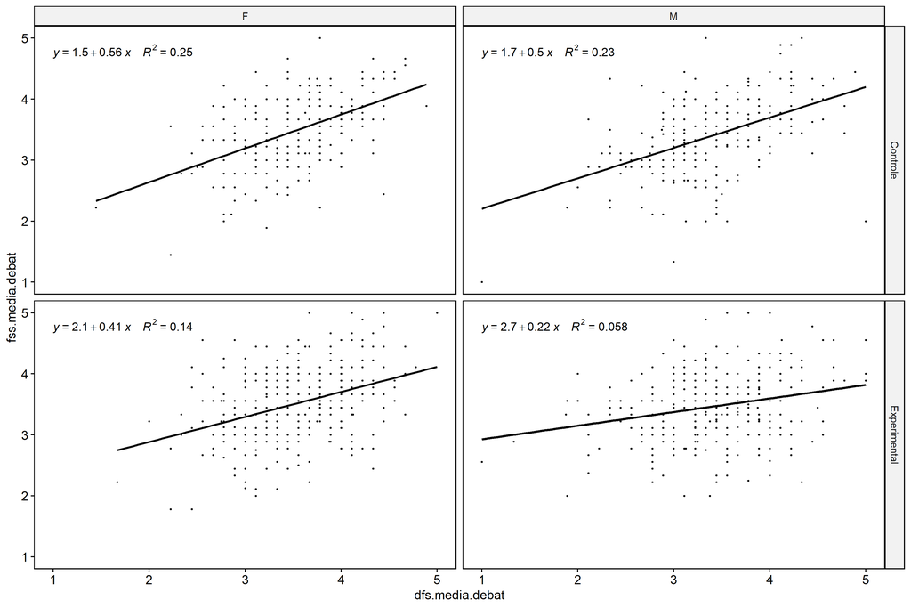

```r
if (length(unique(pdat[["Sexo"]])) >= 2) {
  ggscatter(wdat, x = "dfs.media.debat", y = "fss.media.debat", size = 0.5,
            facet.by = c("grupo","Sexo"), add = "reg.line")+
    stat_regline_equation(
      aes(label =  paste(..eq.label.., ..rr.label.., sep = "~~~~"))
    ) +
    if (ymin < ymax) ggplot2::ylim(ymin, ymax)
}
```

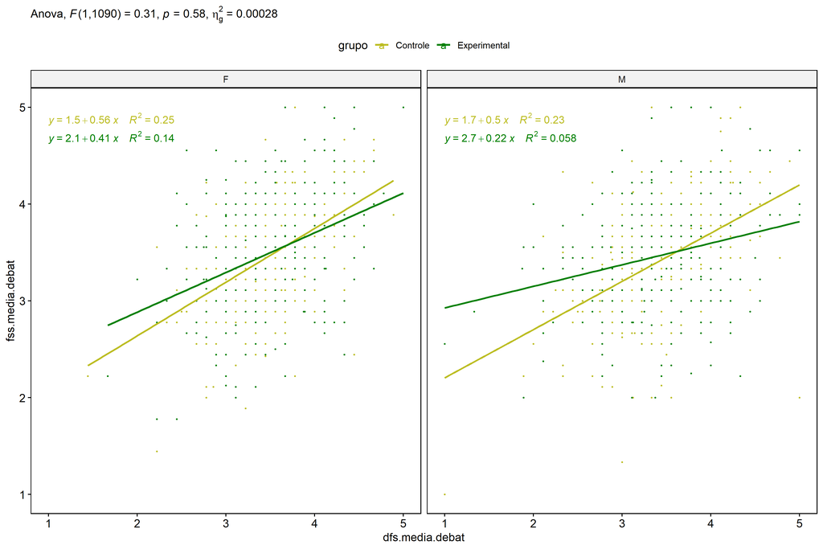

```r
if (length(unique(pdat[["Sexo"]])) >= 2) {
  ggscatter(wdat, x = "dfs.media.debat", y = "fss.media.debat", size = 0.5,
            color = "grupo", facet.by = "Sexo", add = "reg.line")+
    stat_regline_equation(
      aes(label =  paste(..eq.label.., ..rr.label.., sep = "~~~~"), color = grupo)
    ) +
    ggplot2::labs(subtitle = rstatix::get_test_label(aov, detailed = T, row = which(aov$Effect == "grupo:Sexo"))) +
    ggplot2::scale_color_manual(values = color[["grupo"]]) +
    if (ymin < ymax) ggplot2::ylim(ymin, ymax)
}
```

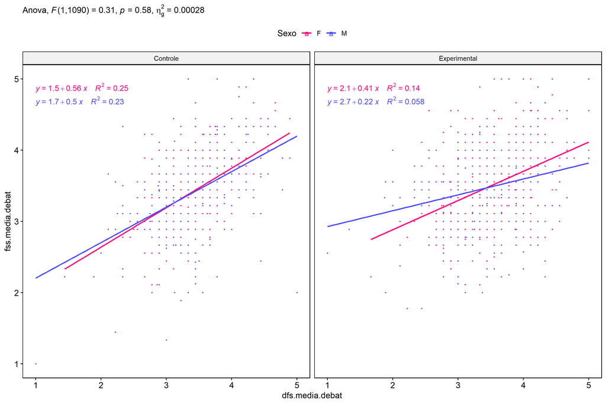

```r
if (length(unique(pdat[["Sexo"]])) >= 2) {
  ggscatter(wdat, x = "dfs.media.debat", y = "fss.media.debat", size = 0.5,
            color = "Sexo", facet.by = "grupo", add = "reg.line")+
    stat_regline_equation(
      aes(label =  paste(..eq.label.., ..rr.label.., sep = "~~~~"), color = Sexo)
    ) +
    ggplot2::labs(subtitle = rstatix::get_test_label(aov, detailed = T, row = which(aov$Effect == "grupo:Sexo"))) +
    ggplot2::scale_color_manual(values = color[["Sexo"]]) +
    if (ymin < ymax) ggplot2::ylim(ymin, ymax)
}
```

### Checking normality and homogeneity

```r
if (length(unique(pdat[["Sexo"]])) >= 2)
  res <- augment(lm(fss.media.debat ~ dfs.media.debat + grupo*Sexo, data = wdat))
```

```r
if (length(unique(pdat[["Sexo"]])) >= 2)
  shapiro_test(res$.resid)
```

```
## # A tibble: 1 × 3
##   variable   statistic p.value
##   <chr>          <dbl>   <dbl>
## 1 res$.resid     0.997  0.0808
```

```r
if (length(unique(pdat[["Sexo"]])) >= 2)
  levene_test(res, .resid ~ grupo*Sexo)
```

```
## # A tibble: 1 × 4
##     df1   df2 statistic     p
##   <int> <int>     <dbl> <dbl>
## 1     3  1091     0.526 0.665
```

# ANCOVA and Pairwise for two factors **grupo:Zona**

## Without remove non-normal data

```r
pdat = remove_group_data(dat[!is.na(dat[["grupo"]]) & !is.na(dat[["Zona"]]),],
                         "fss.media.debat", c("grupo","Zona"))
pdat = pdat[pdat[["Zona"]] %in% do.call(
  intersect, lapply(unique(pdat[["grupo"]]), FUN = function(x) {
    unique(pdat[["Zona"]][which(pdat[["grupo"]] == x)])
  })),]
pdat[["grupo"]] = factor(pdat[["grupo"]], level[["grupo"]])
pdat[["Zona"]] = factor(
  pdat[["Zona"]],
  level[["Zona"]][level[["Zona"]] %in% unique(pdat[["Zona"]])])

pdat.long <- rbind(pdat[,c("id","grupo","Zona")], pdat[,c("id","grupo","Zona")])
pdat.long[["time"]] <- c(rep("pre", nrow(pdat)), rep("pos", nrow(pdat)))
pdat.long[["time"]] <- factor(pdat.long[["time"]], c("pre","pos"))
pdat.long[["flow.debat"]] <- c(pdat[["dfs.media.debat"]], pdat[["fss.media.debat"]])

if (length(unique(pdat[["Zona"]])) >= 2) {
  aov = anova_test(pdat, fss.media.debat ~ dfs.media.debat + grupo*Zona)
  laov[["grupo:Zona"]] <- get_anova_table(aov)
}
```

```r
if (length(unique(pdat[["Zona"]])) >= 2) {
  pwcs <- list()
  pwcs[["Zona"]] <- emmeans_test(
    group_by(pdat, grupo), fss.media.debat ~ Zona,
    covariate = dfs.media.debat, p.adjust.method = "bonferroni")
  pwcs[["grupo"]] <- emmeans_test(
    group_by(pdat, Zona), fss.media.debat ~ grupo,
    covariate = dfs.media.debat, p.adjust.method = "bonferroni")

  pwc <- plyr::rbind.fill(pwcs[["grupo"]], pwcs[["Zona"]])
  pwc <- pwc[,c("grupo","Zona", colnames(pwc)[!colnames(pwc) %in% c("grupo","Zona")])]
}
```

```r
if (length(unique(pdat[["Zona"]])) >= 2) {
  pwc.long <- emmeans_test(dplyr::group_by_at(pdat.long, c("grupo","Zona")),
                           flow.debat ~ time,
                           p.adjust.method = "bonferroni")
  lpwc[["grupo:Zona"]] <- plyr::rbind.fill(pwc, pwc.long)
}
```

```r
if (length(unique(pdat[["Zona"]])) >= 2) {
  ds <- get.descriptives(pdat, "fss.media.debat", c("grupo","Zona"), covar = "dfs.media.debat")
  ds <- merge(ds[ds$variable != "dfs.media.debat",],
              ds[ds$variable == "dfs.media.debat", !colnames(ds) %in% c("variable")],
              by = c("grupo","Zona"), all.x = T, suffixes = c("", ".dfs.media.debat"))
  ds <- merge(get_emmeans(pwcs[["grupo"]]), ds,
              by = c("grupo","Zona"), suffixes = c(".emms", ""))
  ds <- ds[,c("grupo","Zona","n","mean.dfs.media.debat","se.dfs.media.debat","mean","se",
              "emmean","se.emms","conf.low","conf.high")]

  colnames(ds) <- c("grupo","Zona", "N", paste0(c("M","SE")," (pre)"),
                    paste0(c("M","SE"), " (unadj)"),
                    paste0(c("M", "SE"), " (adj)"), "conf.low", "conf.high")

  lemms[["grupo:Zona"]] <- ds
}
```

## Computing ANCOVA and PairWise After removing non-normal data (OK)

```r
if (length(unique(pdat[["Zona"]])) >= 2) {
  wdat = pdat

  res = residuals(lm(fss.media.debat ~ dfs.media.debat + grupo*Zona, data = wdat))
  non.normal = getNonNormal(res, wdat$id, plimit = 0.05)

  wdat = wdat[!wdat$id %in% non.normal,]

  wdat.long <- rbind(wdat[,c("id","grupo","Zona")], wdat[,c("id","grupo","Zona")])
  wdat.long[["time"]] <- c(rep("pre", nrow(wdat)), rep("pos", nrow(wdat)))
  wdat.long[["time"]] <- factor(wdat.long[["time"]], c("pre","pos"))
  wdat.long[["flow.debat"]] <- c(wdat[["dfs.media.debat"]], wdat[["fss.media.debat"]])


  ldat[["grupo:Zona"]] = wdat

  (non.normal)
}
```

```
## [1] "P2207"
```

```r
if (length(unique(pdat[["Zona"]])) >= 2) {
  aov = anova_test(wdat, fss.media.debat ~ dfs.media.debat + grupo*Zona)
  laov[["grupo:Zona"]] <- merge(get_anova_table(aov), laov[["grupo:Zona"]],
                                         by="Effect", suffixes = c("","'"))
  df = get_anova_table(aov)
}
```

| Effect | DFn | DFd | F | p | p<.05 | ges |
| --- | --- | --- | --- | --- | --- | --- |
| dfs.media.debat | 1 | 754 | 157.091 | 0.000 | * | 0.172 |
| grupo | 1 | 754 | 0.581 | 0.446 |  | 0.001 |
| Zona | 1 | 754 | 0.079 | 0.779 |  | 0.000 |
| grupo:Zona | 1 | 754 | 0.853 | 0.356 |  | 0.001 |

```r
if (length(unique(pdat[["Zona"]])) >= 2) {
  pwcs <- list()
  pwcs[["Zona"]] <- emmeans_test(
    group_by(wdat, grupo), fss.media.debat ~ Zona,
    covariate = dfs.media.debat, p.adjust.method = "bonferroni")
  pwcs[["grupo"]] <- emmeans_test(
    group_by(wdat, Zona), fss.media.debat ~ grupo,
    covariate = dfs.media.debat, p.adjust.method = "bonferroni")

  pwc <- plyr::rbind.fill(pwcs[["grupo"]], pwcs[["Zona"]])
  pwc <- pwc[,c("grupo","Zona", colnames(pwc)[!colnames(pwc) %in% c("grupo","Zona")])]
}
```

| grupo | Zona | term | .y. | group1 | group2 | df | statistic | p | p.adj | p.adj.signif |
| --- | --- | --- | --- | --- | --- | --- | --- | --- | --- | --- |
|  | Rural | dfs.media.debat*grupo | fss.media.debat | Controle | Experimental | 754 | -1.165 | 0.244 | 0.244 | ns |
|  | Urbana | dfs.media.debat*grupo | fss.media.debat | Controle | Experimental | 754 | 0.281 | 0.779 | 0.779 | ns |
| Controle |  | dfs.media.debat*Zona | fss.media.debat | Rural | Urbana | 754 | -0.522 | 0.602 | 0.602 | ns |
| Experimental |  | dfs.media.debat*Zona | fss.media.debat | Rural | Urbana | 754 | 0.814 | 0.416 | 0.416 | ns |

```r
if (length(unique(pdat[["Zona"]])) >= 2) {
  pwc.long <- emmeans_test(dplyr::group_by_at(wdat.long, c("grupo","Zona")),
                           flow.debat ~ time,
                           p.adjust.method = "bonferroni")
  lpwc[["grupo:Zona"]] <- merge(plyr::rbind.fill(pwc, pwc.long),
                                         lpwc[["grupo:Zona"]],
                                         by=c("grupo","Zona","term",".y.","group1","group2"),
                                         suffixes = c("","'"))
}
```

| grupo | Zona | term | .y. | group1 | group2 | df | statistic | p | p.adj | p.adj.signif |
| --- | --- | --- | --- | --- | --- | --- | --- | --- | --- | --- |
| Controle | Rural | time | flow.debat | pre | pos | 1510 | 0.749 | 0.454 | 0.454 | ns |
| Controle | Urbana | time | flow.debat | pre | pos | 1510 | -0.687 | 0.492 | 0.492 | ns |
| Experimental | Rural | time | flow.debat | pre | pos | 1510 | -1.216 | 0.224 | 0.224 | ns |
| Experimental | Urbana | time | flow.debat | pre | pos | 1510 | 0.214 | 0.831 | 0.831 | ns |

```r
if (length(unique(pdat[["Zona"]])) >= 2) {
  ds <- get.descriptives(wdat, "fss.media.debat", c("grupo","Zona"), covar = "dfs.media.debat")
  ds <- merge(ds[ds$variable != "dfs.media.debat",],
              ds[ds$variable == "dfs.media.debat", !colnames(ds) %in% c("variable")],
              by = c("grupo","Zona"), all.x = T, suffixes = c("", ".dfs.media.debat"))
  ds <- merge(get_emmeans(pwcs[["grupo"]]), ds,
              by = c("grupo","Zona"), suffixes = c(".emms", ""))
  ds <- ds[,c("grupo","Zona","n","mean.dfs.media.debat","se.dfs.media.debat",
              "mean","se","emmean","se.emms","conf.low","conf.high")]

  colnames(ds) <- c("grupo","Zona", "N", paste0(c("M","SE")," (pre)"),
                    paste0(c("M","SE"), " (unadj)"),
                    paste0(c("M", "SE"), " (adj)"), "conf.low", "conf.high")

  lemms[["grupo:Zona"]] <- merge(ds, lemms[["grupo:Zona"]],
                                          by=c("grupo","Zona"), suffixes = c("","'"))
}
```

| grupo | Zona | N | M (pre) | SE (pre) | M (unadj) | SE (unadj) | M (adj) | SE (adj) | conf.low | conf.high |
| --- | --- | --- | --- | --- | --- | --- | --- | --- | --- | --- |
| Controle | Rural | 228 | 3.510 | 0.035 | 3.469 | 0.038 | 3.449 | 0.035 | 3.380 | 3.518 |
| Controle | Urbana | 110 | 3.402 | 0.060 | 3.455 | 0.060 | 3.481 | 0.051 | 3.381 | 3.581 |
| Experimental | Rural | 248 | 3.428 | 0.036 | 3.491 | 0.036 | 3.506 | 0.034 | 3.439 | 3.572 |
| Experimental | Urbana | 173 | 3.487 | 0.044 | 3.473 | 0.046 | 3.463 | 0.040 | 3.383 | 3.542 |

### Plots for ancova

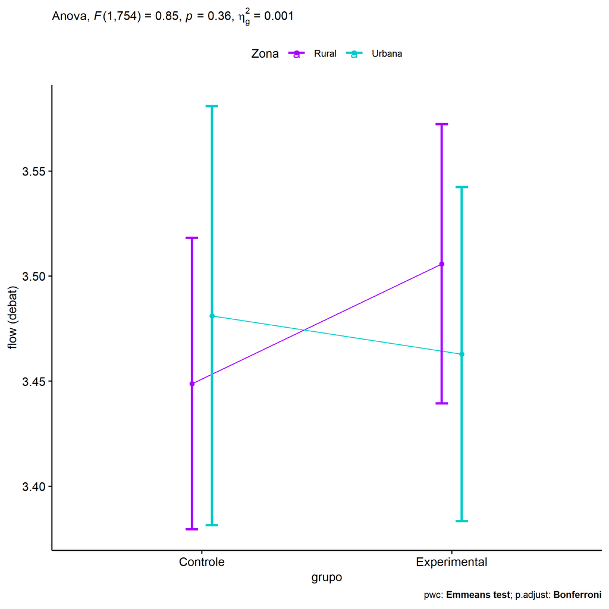

```r
if (length(unique(pdat[["Zona"]])) >= 2) {
  ggPlotAoC2(pwcs, "grupo", "Zona", aov, ylab = "flow (debat)",
             subtitle = which(aov$Effect == "grupo:Zona"), addParam = "errorbar") +
    ggplot2::scale_color_manual(values = color[["Zona"]]) +
    if (ymin.ci < ymax.ci) ggplot2::ylim(ymin.ci, ymax.ci)
}
```

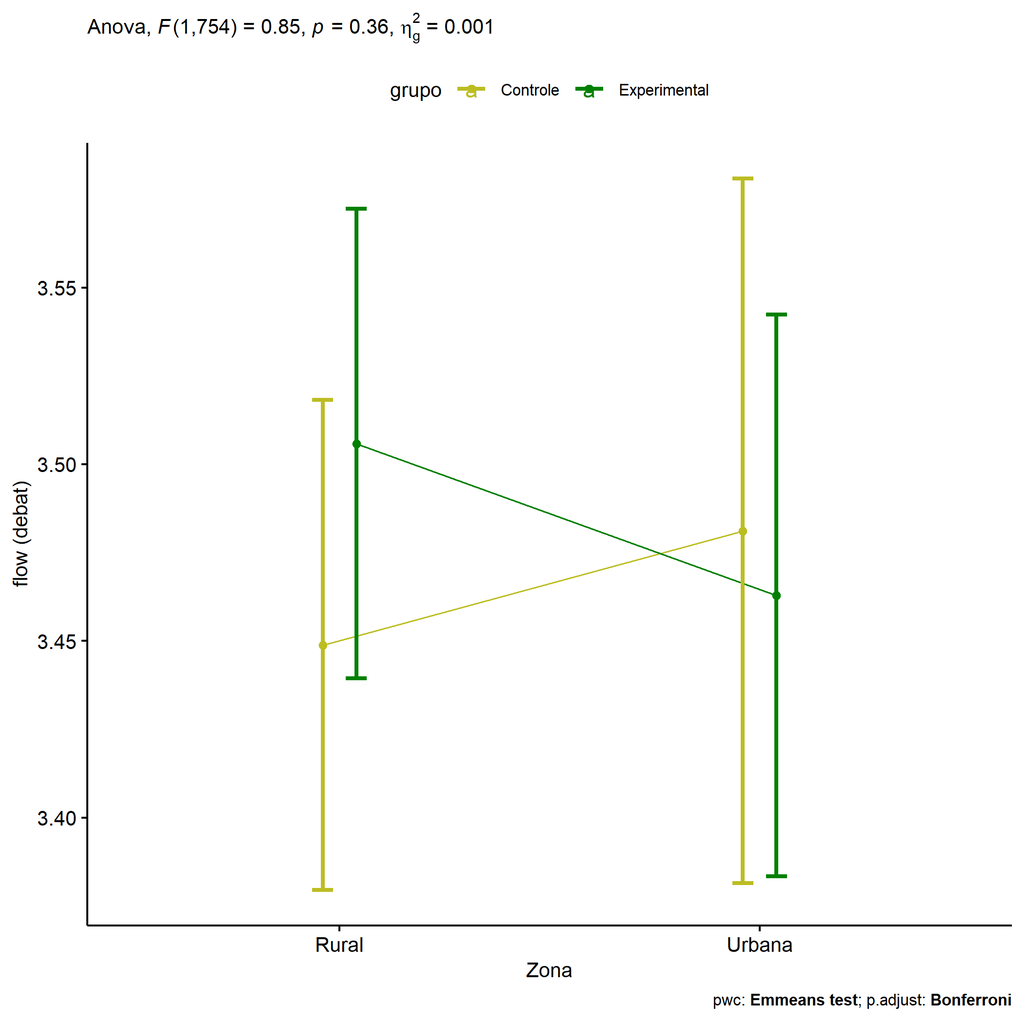

```r
if (length(unique(pdat[["Zona"]])) >= 2) {
  ggPlotAoC2(pwcs, "Zona", "grupo", aov, ylab = "flow (debat)",
               subtitle = which(aov$Effect == "grupo:Zona"), addParam = "errorbar") +
      ggplot2::scale_color_manual(values = color[["grupo"]]) +
      if (ymin.ci < ymax.ci) ggplot2::ylim(ymin.ci, ymax.ci)
}
```

```r
if (length(unique(pdat[["Zona"]])) >= 2) {
  plots <- twoWayAncovaBoxPlots(
    wdat, "fss.media.debat", c("grupo","Zona"), aov, pwcs, covar = "dfs.media.debat",
    theme = "classic", color = color[["grupo:Zona"]],
    subtitle = which(aov$Effect == "grupo:Zona"))
}
```

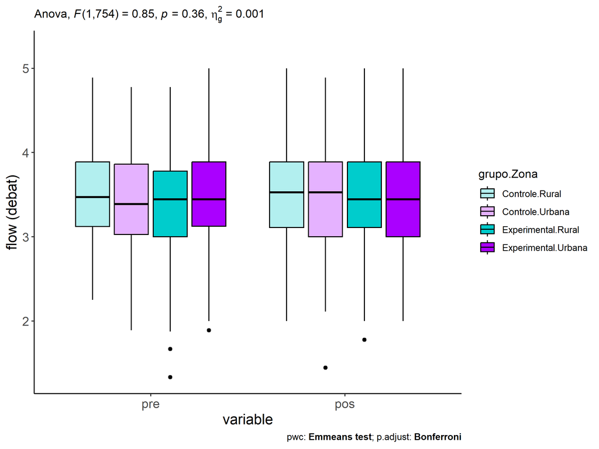

```r
if (length(unique(pdat[["Zona"]])) >= 2) {
  plots[["grupo:Zona"]] + ggplot2::ylab("flow (debat)") +
  ggplot2::scale_x_discrete(labels=c('pre', 'pos')) +
  if (ymin < ymax) ggplot2::ylim(ymin, ymax)
}
```

```r
if (length(unique(pdat[["Zona"]])) >= 2) {
  plots <- twoWayAncovaBoxPlots(
    wdat.long, "flow.debat", c("grupo","Zona"), aov, pwc.long,
    pre.post = "time",
    theme = "classic", color = color$prepost)
}
```

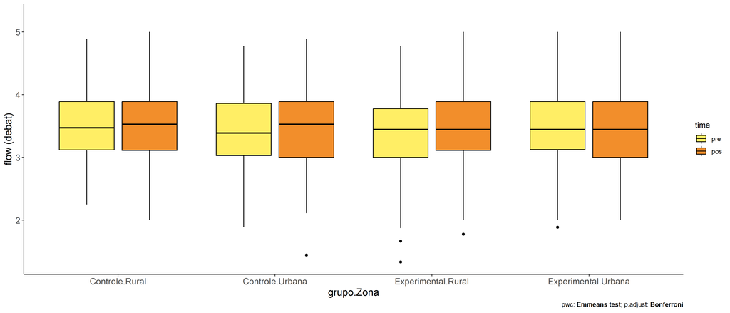

```r
if (length(unique(pdat[["Zona"]])) >= 2)
  plots[["grupo:Zona"]] + ggplot2::ylab("flow (debat)") +
    if (ymin < ymax) ggplot2::ylim(ymin, ymax)
```

### Checking linearity assumption

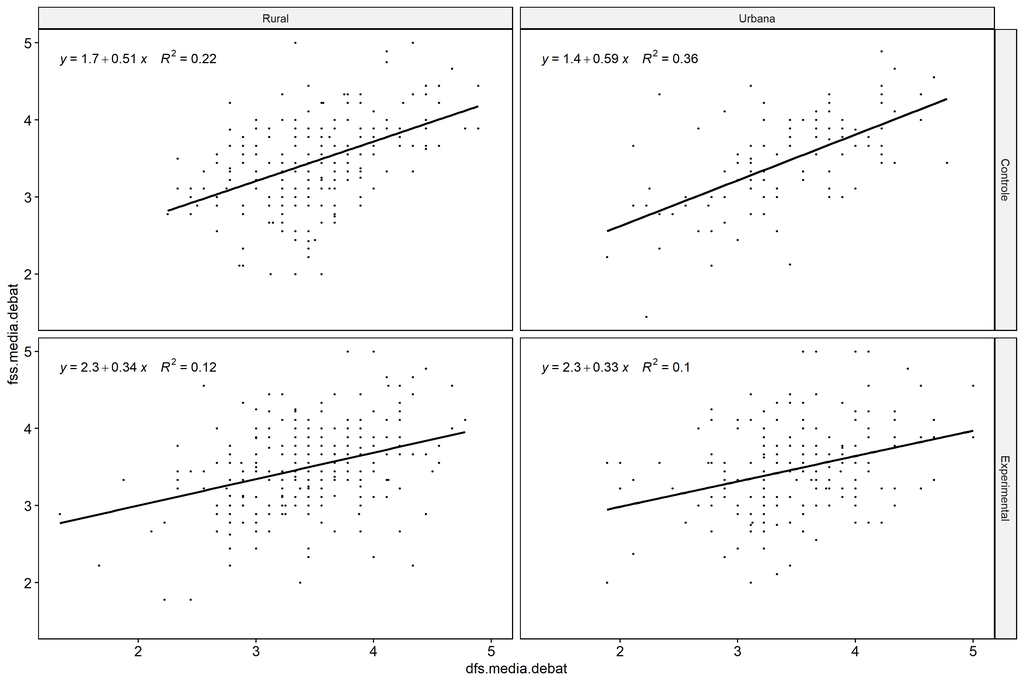

```r
if (length(unique(pdat[["Zona"]])) >= 2) {
  ggscatter(wdat, x = "dfs.media.debat", y = "fss.media.debat", size = 0.5,
            facet.by = c("grupo","Zona"), add = "reg.line")+
    stat_regline_equation(
      aes(label =  paste(..eq.label.., ..rr.label.., sep = "~~~~"))
    ) +
    if (ymin < ymax) ggplot2::ylim(ymin, ymax)
}
```

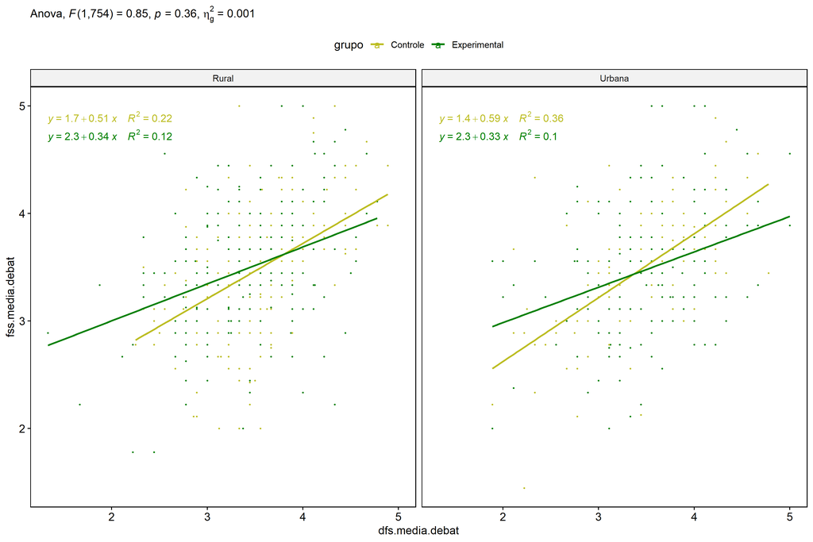

```r
if (length(unique(pdat[["Zona"]])) >= 2) {
  ggscatter(wdat, x = "dfs.media.debat", y = "fss.media.debat", size = 0.5,
            color = "grupo", facet.by = "Zona", add = "reg.line")+
    stat_regline_equation(
      aes(label =  paste(..eq.label.., ..rr.label.., sep = "~~~~"), color = grupo)
    ) +
    ggplot2::labs(subtitle = rstatix::get_test_label(aov, detailed = T, row = which(aov$Effect == "grupo:Zona"))) +
    ggplot2::scale_color_manual(values = color[["grupo"]]) +
    if (ymin < ymax) ggplot2::ylim(ymin, ymax)
}
```

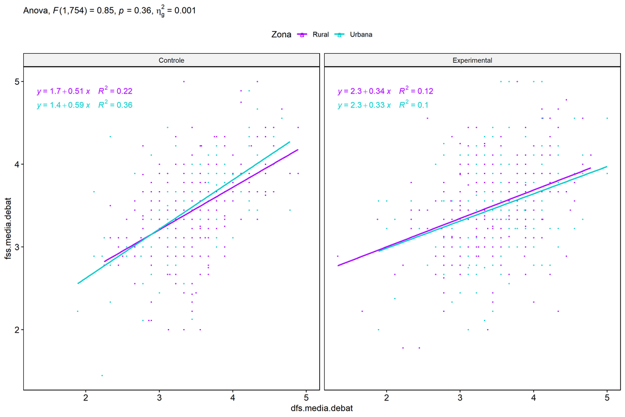

```r
if (length(unique(pdat[["Zona"]])) >= 2) {
  ggscatter(wdat, x = "dfs.media.debat", y = "fss.media.debat", size = 0.5,
            color = "Zona", facet.by = "grupo", add = "reg.line")+
    stat_regline_equation(
      aes(label =  paste(..eq.label.., ..rr.label.., sep = "~~~~"), color = Zona)
    ) +
    ggplot2::labs(subtitle = rstatix::get_test_label(aov, detailed = T, row = which(aov$Effect == "grupo:Zona"))) +
    ggplot2::scale_color_manual(values = color[["Zona"]]) +
    if (ymin < ymax) ggplot2::ylim(ymin, ymax)
}
```

### Checking normality and homogeneity

```r
if (length(unique(pdat[["Zona"]])) >= 2)
  res <- augment(lm(fss.media.debat ~ dfs.media.debat + grupo*Zona, data = wdat))
```

```r
if (length(unique(pdat[["Zona"]])) >= 2)
  shapiro_test(res$.resid)
```

```
## # A tibble: 1 × 3
##   variable   statistic p.value
##   <chr>          <dbl>   <dbl>
## 1 res$.resid     0.998   0.595
```

```r
if (length(unique(pdat[["Zona"]])) >= 2)
  levene_test(res, .resid ~ grupo*Zona)
```

```
## # A tibble: 1 × 4
##     df1   df2 statistic     p
##   <int> <int>     <dbl> <dbl>
## 1     3   755      1.48 0.219
```

# ANCOVA and Pairwise for two factors **grupo:Cor.Raca**

## Without remove non-normal data

```r
pdat = remove_group_data(dat[!is.na(dat[["grupo"]]) & !is.na(dat[["Cor.Raca"]]),],
                         "fss.media.debat", c("grupo","Cor.Raca"))
pdat = pdat[pdat[["Cor.Raca"]] %in% do.call(
  intersect, lapply(unique(pdat[["grupo"]]), FUN = function(x) {
    unique(pdat[["Cor.Raca"]][which(pdat[["grupo"]] == x)])
  })),]
pdat[["grupo"]] = factor(pdat[["grupo"]], level[["grupo"]])
pdat[["Cor.Raca"]] = factor(
  pdat[["Cor.Raca"]],
  level[["Cor.Raca"]][level[["Cor.Raca"]] %in% unique(pdat[["Cor.Raca"]])])

pdat.long <- rbind(pdat[,c("id","grupo","Cor.Raca")], pdat[,c("id","grupo","Cor.Raca")])
pdat.long[["time"]] <- c(rep("pre", nrow(pdat)), rep("pos", nrow(pdat)))
pdat.long[["time"]] <- factor(pdat.long[["time"]], c("pre","pos"))
pdat.long[["flow.debat"]] <- c(pdat[["dfs.media.debat"]], pdat[["fss.media.debat"]])

if (length(unique(pdat[["Cor.Raca"]])) >= 2) {
  aov = anova_test(pdat, fss.media.debat ~ dfs.media.debat + grupo*Cor.Raca)
  laov[["grupo:Cor.Raca"]] <- get_anova_table(aov)
}
```

```r
if (length(unique(pdat[["Cor.Raca"]])) >= 2) {
  pwcs <- list()
  pwcs[["Cor.Raca"]] <- emmeans_test(
    group_by(pdat, grupo), fss.media.debat ~ Cor.Raca,
    covariate = dfs.media.debat, p.adjust.method = "bonferroni")
  pwcs[["grupo"]] <- emmeans_test(
    group_by(pdat, Cor.Raca), fss.media.debat ~ grupo,
    covariate = dfs.media.debat, p.adjust.method = "bonferroni")

  pwc <- plyr::rbind.fill(pwcs[["grupo"]], pwcs[["Cor.Raca"]])
  pwc <- pwc[,c("grupo","Cor.Raca", colnames(pwc)[!colnames(pwc) %in% c("grupo","Cor.Raca")])]
}
```

```r
if (length(unique(pdat[["Cor.Raca"]])) >= 2) {
  pwc.long <- emmeans_test(dplyr::group_by_at(pdat.long, c("grupo","Cor.Raca")),
                           flow.debat ~ time,
                           p.adjust.method = "bonferroni")
  lpwc[["grupo:Cor.Raca"]] <- plyr::rbind.fill(pwc, pwc.long)
}
```

```r
if (length(unique(pdat[["Cor.Raca"]])) >= 2) {
  ds <- get.descriptives(pdat, "fss.media.debat", c("grupo","Cor.Raca"), covar = "dfs.media.debat")
  ds <- merge(ds[ds$variable != "dfs.media.debat",],
              ds[ds$variable == "dfs.media.debat", !colnames(ds) %in% c("variable")],
              by = c("grupo","Cor.Raca"), all.x = T, suffixes = c("", ".dfs.media.debat"))
  ds <- merge(get_emmeans(pwcs[["grupo"]]), ds,
              by = c("grupo","Cor.Raca"), suffixes = c(".emms", ""))
  ds <- ds[,c("grupo","Cor.Raca","n","mean.dfs.media.debat","se.dfs.media.debat","mean","se",
              "emmean","se.emms","conf.low","conf.high")]

  colnames(ds) <- c("grupo","Cor.Raca", "N", paste0(c("M","SE")," (pre)"),
                    paste0(c("M","SE"), " (unadj)"),
                    paste0(c("M", "SE"), " (adj)"), "conf.low", "conf.high")

  lemms[["grupo:Cor.Raca"]] <- ds
}
```